# blocking: An R Package for Blocking of Records for Record Linkage and Deduplication

Entity resolution (probabilistic record linkage, deduplication) is essential for bringing together data needed for estimation or other analyses based on multiple sources. It aims to link records that refer to the same entity (e.g., person, company) in the absence of unique identifiers. Without identifiers, researchers must specify which records to compare to calculate matching probability and reduce computational complexity. Traditional deterministic blocking uses common variables like first letters of names, sex, or dates of birth, but assumes error-free, complete data. To address this limitation, we developed the R package **blocking**, which uses approximate nearest neighbour search and graph algorithms to reduce the number of comparisons. This paper presents the package design, functionalities, and two case studies.

Maciej Beręsewicz https://maciejberesewicz.com (University of Economics and BusinessStatistical Office in Poznań) , Adam Struzik (Adam Mickiewicz UniversityStatistical Office in Poznań)  
2026-03-11

## 1 Introduction

### 1.1 Blocking for record linkage

Entity resolution (probabilistic record linkage, deduplication) is essential for bringing together data needed for estimation or other analyses based on multiple sources (cf. Fellegi and Sunter (1969), Binette and Steorts (2022)). The goal is to link records that refer to the same entity (e.g., person, company, job position) in the absence of unique identifiers. This situation is frequently observed in administrative records, e.g., for foreign-national populations. For instance, the Social Insurance Institution register in Poland at the end of 2023 included 1.206 million records referring to approximately 1.105 million individuals, of which about 10% had missing information in the personal identifier (PESEL) and about 50% had missing address details. Note that the exact number of individuals is certainly lower than 1.105 million, as the 10% with missing identifiers may include duplicates (cf. Beręsewicz (2025)).

This drives the need to link records without unique identifiers, which often requires certain assumptions about how to reduce the large number of possible comparisons, as it is not feasible to compare all pairs of records in large datasets (e.g., the aforementioned example would require over 700 billion comparisons). Consequently, researchers aim to reduce the number of comparisons in various ways prior to the record linkage/deduplication stage. The rationale is twofold: computational resource constraints and clerical review workload (cf. Christen (2012b)).

Reducing the number of comparisons is accomplished through blocking, a method that limits possible comparisons by assuming that certain variables must match exactly or that combinations of variables should match above a specified threshold. For instance, a standard approach assumes that sex or birth year must match exactly, while other record characteristics may vary. Another method employs phonetic algorithms such as Soundex (cf. Knuth (1973)) or its adaptations for non-English languages (cf. Howard II (2020)) to block records that sound similar but are spelt differently (e.g., Smith and Smyth, or Anna and Ania). Furthermore, with the growing popularity of large language models (both closed and open-source), one may consider using embeddings (Mikolov et al. 2013) to identify nearest neighbours and treat these as potential comparison pairs. For a comprehensive review of blocking methods, see Christen (2012a), Steorts et al. (2014), or Papadakis et al. (2020). Section 1.2 discusses existing R packages that implement blocking methods.

Reducing the number of pairs has inherent costs: missed comparisons lead to increased false positive rates (FPR) and false negative rates (FNR) in linkage studies. To validate the blocking strategy, a subset of true pairs should be provided, or simulation studies of proposed methods should be conducted. Alternatively, one may consider approaches proposed by Dasylva and Goussanou (2021) and Dasylva and Goussanou (2022), who demonstrated how to estimate FPR and FNR without access to an audit sample.

### 1.2 Existing software and our contribution

The R ecosystem offers several packages that implement various blocking techniques, which we have grouped according to the following classification:

- **Deterministic blocking**:
  - reclin2 (van der Laan (2024), van der Laan (2022)) allows pairing records using `pair_blocking()` with a prespecified list of columns in a `data.frame`, and the `pair_minsim()` function, which allows specifying the minimal similarity score (e.g., 1 out of 3 variable values must match exactly).
  - RecordLinkage (Sariyar and Borg (2025), Sariyar and Borg (2010)) allows specifying blocking variables in the `blockfld` parameter of either `compare.dedup()` or `compare.linkage()` functions as a vector (either character or numeric).
  - fastLink (Enamorado et al. (2023), Enamorado et al. (2019)) implements various blocking methods via the `blockData()` function, including exact matching, window matching (e.g., no more than 2-year difference between birth years), and $k$-means clustering. Notably, `fastLink` returns datasets split into separate lists, while `reclin2` and `RecordLinkage` packages create a single dataset.
  - PPRL (Schnell and Rukasz (2025)) focuses on privacy preserving deterministic and probabilistic record linkage and implements exact blocking via the `SelectBlockingFunction()` function.
- **Phonetic blocking**:
  - RecordLinkage allows direct specification of phonetic comparison via the `phonetic` argument in `compare.dedup()` or `compare.linkage()` functions using the `soundex()` function.
  - Additionally, stringdist (van der Loo 2014) implements the Soundex algorithm, while phonics (Howard II 2021) implements various phonetic algorithms that can be applied prior to the blocking procedure (e.g., to create a new column).
- **Probabilistic blocking**:
  - klsh (Steorts 2020) is the only R package that implements probabilistic blocking using the $k$-means variant of locality sensitive hashing. The main `klsh()` function implements this approach, and the resulting object is a list containing row identifiers for the prespecified number of blocks (via the `num.blocks` argument).

In practice, the situation is more complicated, as missing data may be present in blocking/matching variables (such as birth dates) or typos may occur in names and surnames. Therefore, we developed blocking, which leverages approximate nearest neighbour (ANN) algorithms and graphs to create numerous small blocks that can be used in subsequent analysis. ANN algorithms are methods designed to efficiently find the closest matches to a query point in a large dataset by trading off search accuracy for computational speed. Unlike exact nearest neighbour search, ANN algorithms do not guarantee finding the true nearest neighbours but are able to identify close approximations substantially faster (cf. Indyk and Motwani (1998), Wang et al. (2021)), making them naturally suited to noisy or incomplete data. This approach is similar to micro-clustering (cf. Johndrow et al. (2018)), but we do not aim at providing the final linkage of units between or within sources.

The basic workflow of the blocking package consists of the following steps as shown in Figure 1.

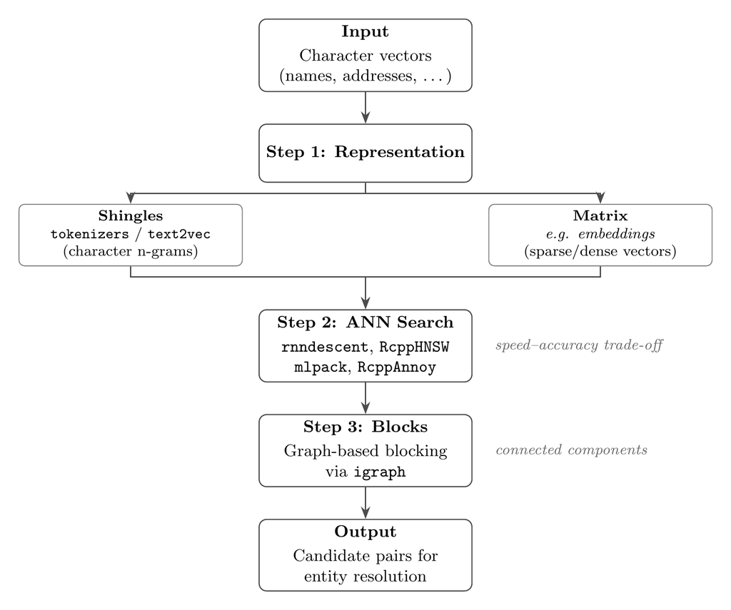

Figure 1: Workflow of the `blocking()` function

These steps can be explained as follows:

1. Create shingles (n-character sequences, e.g. `"home"` will be `c("ho", "om", "me")`) of the input character vectors using either tokenizers (Mullen et al. 2018) or text2vec (Selivanov et al. 2023). The former tokenises strings into character n-grams, while the latter additionally provides term-frequency weighting. Alternatively, the user may provide a matrix of vector representations of the input strings. Such representations, known as embeddings, encode semantic or contextual similarity between strings as dense numeric vectors. Embeddings can be obtained, for example, via ragnar (Kalinowski and Falbel 2025), a package that provides an interface to large language models for generating text embeddings (either static or dynamic). An example using embeddings is provided in the Supplementary Materials.
2. Search for nearest neighbours using ANN algorithms implemented in rnndescent (the only one allowing for sparse matrices, cf. Melville (2024b)), RcppHNSW (Melville 2024a), mlpack (Curtin et al. (2023), Singh Parihar et al. (2025)), and RcppAnnoy (Eddelbuettel 2024).
3. Create final blocks using igraph (Csárdi et al. (2025), Csardi and Nepusz (2006)).

This is the only package in the R ecosystem that readily applies modern ANN algorithms to reduce the number of comparisons and substantially accelerate record linkage and deduplication tasks. Additionally, we have developed the `pair_ann()` function for seamless integration with the reclin2 package, as described in the package vignette entitled [`"Integration with existing packages"`](https://cran.r-project.org/web/packages/blocking/vignettes/v3-integration.html). The blocking package is not limited to the reclin2 and can be applied in various record linkage or deduplication contexts. Furthermore, one can combine results from our package with deterministic methods, e.g., by blocking on the first letter of a variable in addition to the ANN-based candidate pairs.

### 1.3 Outline of the article

This paper is structured as follows. Section 2 provides a description of the main functionalities of the blocking package and how results can be evaluated. Section 3 presents two case studies: probabilistic record linkage and deduplication. These examples demonstrate how our package can improve the entity resolution pipeline and integrate with existing R packages.

## 2 Blocking of records using `blocking()` function

### 2.1 The main function

The main functionality is available via the `blocking()` function, which contains the following key arguments:

- `x, y` – vectors of keys used for linkage, where `y = NULL` indicates a deduplication task;
- `representation` – whether `x` and `y` should be represented as shingles, a custom matrix, or vectors (e.g., provided by the user via the `model` argument);
- `ann` – which ANN algorithm should be applied (by default, we use the rnndescent package as it supports sparse matrices);
- `distance` – which distance metric should be applied (default is `cosine` distance);
- `graph` – whether a plot of the graph showing connected records should be returned (default `FALSE`);
- `true_blocks` – if a subset of true blocks is available, it can be provided here so that quality measures, presented in the next section, are returned;
- `n_threads` – number of threads used for computation;
- `control_txt` – controls provided via `controls_txt()` specifying how `x, y` are processed;
- `control_ann` – controls provided via `controls_ann()` allowing users to fine-tune the ANN algorithm (see documentation for the `controls_ann()` function and `control_*` functions with names referring to specific algorithms, e.g., `control_nnd()` for the NND algorithm).

This function returns an object of class `blocking` containing the following elements:

- `result` – a `data.table` with indices (rows) of x, y, block, and distance between points;
- `method` – name of the ANN algorithm used;
- `deduplication` – information about whether deduplication was applied;
- `representation` – information about whether shingles, a custom matrix, or vectors were used;
- `metrics` – quality assessment metrics, if `true_blocks` is provided;
- `confusion` – confusion matrix, if `true_blocks` is provided;
- `colnames` – variable names (`colnames`) used for search;
- `graph` – an `igraph` class object.

### 2.2 Assessment of results

The package implements several measures that can be used to assess results. The first is the *reduction ratio* (RR, cf. Christen and Goiser (2007)), which indicates the reduction in comparison pairs within the given blocks. It has a value between $[0,1]$, where 1 indicates perfect reduction while values close to 0 indicate poor reduction. The RR indicator for deduplication has the following form:

$$\text{RR}_{\text{dedup}} = 1 - \frac{\sum\limits_{i=1}^{k} \binom{|B_i|}{2}}{\binom{n}{2}},$$

where $k$ is the total number of blocks, $n$ is the total number of records in the dataset, and $|B_i|$ is the number of records in the $i$-th block. $\sum\limits_{i=1}^{k} \binom{|B_i|}{2}$ is the number of comparisons after blocking, while $\binom{n}{2}$ is the total number of possible comparisons without blocking. For record linkage, the reduction ratio is defined as follows:

$$\text{RR}_{\text{reclin}} = 1 - \frac{\sum\limits_{i=1}^{k} |B_{i,x}| \cdot |B_{i,y}|} {m \cdot n},$$

where $m$ and $n$ are the sizes of datasets $X$ and $Y$, and $k$ is the total number of blocks. The term $|B_{i,x}|$ is the number of records from dataset $X$ in the $i$-th block, while $|B_{i,y}|$ is the number of records from dataset $Y$ in the $i$-th block. The expression $\sum\limits_{i=1}^{k} |B_{i,x}| \cdot |B_{i,y}|$ represents the number of comparisons after blocking.

Another way to assess blocking is to examine the confusion matrix at the *block* level, i.e., blocking results are compared with ground-truth *blocks* in a pairwise manner (e.g., one true positive pair occurs when both records from the comparison pair belong to the same predicted *block* and to the same ground-truth *block* in the evaluation `data.frame`). The values in this table are defined as follows:

- True Positive (TP): Record pairs correctly matched in the same block.
- False Positive (FP): Record pairs identified as matches that are not true matches in the same block.
- True Negative (TN): Record pairs correctly identified as non-matches (different blocks).
- False Negative (FN): Record pairs identified as non-matches that are true matches in the same block.

Metrics calculated based on this confusion matrix are defined in Table 1. In the context of blocking, these metrics are interpreted as follows:

- Accuracy: The ability to discriminate true pairs (both matches and non-matches).
- Precision (Positive Predictive Value, or Pairs Quality): The proportion of true matches among the candidate pairs. In blocking, it is expected to be lower than in final linkage.
- False Positive Rate (FPR): The share of non-matches incorrectly included in the blocks. It is expected to be low as pairs of non-links should be spotted as True Negatives.
- False Negative Rate (FNR): The share of matches missed by blocking. It is expected to be low as blocking should discover all pairs one wants to compare in entity resolution.
- F1 Score: Combines precision and FNR. However, it may be less relevant in the context of blocking, since low precision and low FNR are expected. For a critique of the F1 score in the context of record linkage see Hand and Christen (2018), and for an alternative F* measure see Hand et al. (2021) (not yet implemented).

Table 1: Evaluation Metrics

| **Metric** | **Formula** | **Metric** | **Formula** |
| --- | --- | --- | --- |
| Accuracy | $\frac{TP + TN}{TP + TN + FP + FN}$ | Precision | $\frac{TP}{TP + FP}$ |
| False Positive Rate | $\frac{FP}{FP + TN}$ | False Negative Rate | $\frac{FN}{FN + TP}$ |
| F1 Score | $2 \cdot \frac{\text{Precision} \cdot (1 - \text{FNR})}{\text{Precision} + (1 - \text{FNR})}$ |  |  |

The `blocking()` function also returns recall (sensitivity, or pairs completeness) and specificity, defined as $\text{Recall} = 1 - \text{FNR}$ and $\text{Specificity} = 1 - \text{FPR}$.

## 3 Case studies

### 3.1 An example of blocking for record linkage

Let us first load the required packages.

```r
library("blocking")
library("data.table")
library("reclin2")
```

We demonstrate the use of the `blocking()` function for record linkage on the `foreigners` dataset included in the package. This fictional representation of the foreign population in Poland was generated based on publicly available information, preserving the distributions from administrative registers. It contains 110,000 rows with 100,000 entities (thus containing 10,000 duplicates). Each row represents one record, with the following columns: `fname` – first name, `sname` – second name, `surname` – surname, `date` – date of birth, `region` – region (county), `country` – country, and `true_id` – a person identifier.

Next, we load the data and examine the first six records.

```r
data("foreigners")
setDT(foreigners)
head(foreigners)
```

```
    fname  sname    surname       date region country true_id
   <char> <char>     <char>     <char> <char>  <char>   <num>
1:   emin            imanov 1998/02/05            031       0
2: nurlan        suleymanli 2000/08/01            031       1
3:   amio        maharrsmov 1939/03/08            031       2
4:   amik        maharramof 1939/03/08            031       2
5:   amil        maharramov 1993/03/08            031       2
6:  gadir        jahangirov 1991/08/29            031       3
```

In the next step, we split the dataset into two separate `data.frame`s: one containing the first appearance of each entity in the `foreigners` dataset, and the other containing subsequent appearances. We then add row identifiers (`x` and `y`).

```r
foreigners_1 <- foreigners[!duplicated(foreigners$true_id), ]
foreigners_1[, x := 1:.N]
foreigners_2 <- foreigners[duplicated(foreigners$true_id), ]
foreigners_2[, y := 1:.N]
```

Now, in both datasets we remove separators from the date column and create a new character column that concatenates information from all columns (excluding `true_id`) in each row. In computer science, this is called schema-agnostic blocking (cf. Papadakis et al. (2016)). Information stored in the `txt` column will be used for blocking records in the `blocking()` function.

```r
foreigners_1[, txt := paste0(fname, sname, surname, gsub("/", "", date),
                             region, country)]
foreigners_2[, txt := paste0(fname, sname, surname, gsub("/", "", date),
                             region, country)]
head(foreigners_1[, .(true_id, txt)])
```

```
   true_id                           txt
     <num>                        <char>
1:       0         eminimanov19980205031
2:       1   nurlansuleymanli20000801031
3:       2     amiomaharrsmov19390308031
4:       3    gadirjahangirov19910829031
5:       4 zaurbayramova1996100601261031
6:       5       asifmammadov19970726031
```

The default algorithm is the Nearest Neighbour Descent Method (Dong et al. 2011) implemented in the rnndescent package. Note that a default parameter of the `blocking()` function is `seed = 2023`, which sets the random seed.

```r
result_reclin <- blocking(x = foreigners_1$txt,
                          y = foreigners_2$txt)
```

Now, we can examine the results by printing the `result_reclin` object. In this example, we have created 6,470 blocks utilizing 1,232 2-character shingles. Blocks are small, as we have 3,920 blocks of 2 elements, 1,599 blocks of 3 elements, …, 2 blocks of 7 elements.

```r
result_reclin
```

```
========================================================
Blocking based on the nnd method.
Number of blocks: 6470.
Number of columns used for blocking: 1232.
Reduction ratio: 0.9999.
========================================================
Distribution of the size of the blocks:
   2    3    4    5    6    7
3920 1599  928   19    2    2
```

To access the result, one should use `result_reclin$result`. The resulting data.table has four columns (as presented below):

- `x` – reference dataset (i.e., `foreigners_1`) – this may not contain all units of `foreigners_1`;
- `y` – query (each row of `foreigners_2`) – this will contain all units of `foreigners_2`;
- `block` – the block identifier;
- `dist` – distance between pairs.

```r
head(result_reclin$result)
```

```
       x     y block      dist
   <int> <int> <num>     <num>
1:     3     1     1 0.2216882
2:     3     2     1 0.2122737
3:    21     3     2 0.1172652
4:    57     4     3 0.1863238
5:    57     5     3 0.1379310
6:    61     6     4 0.2307692
```

Let’s examine the first block. Clearly, there are typos in the `fname` and `surname`. Nevertheless, all records refer to the same entity (as denoted by `true_id`).

```r
rbind(foreigners_1[3, 1:7], foreigners_2[1:2, 1:7])
```

```
    fname  sname    surname       date region country true_id
   <char> <char>     <char>     <char> <char>  <char>   <num>
1:   amio        maharrsmov 1939/03/08            031       2
2:   amik        maharramof 1939/03/08            031       2
3:   amil        maharramov 1993/03/08            031       2
```

Now we use the `true_id` column to evaluate our approach.

```r
matches <- merge(x = foreigners_1[, .(x, true_id)],
                 y = foreigners_2[, .(y, true_id)],
                 by = "true_id")
matches[, block := rleid(x)]
head(matches)
```

```
Key: <true_id>
   true_id     x     y block
     <num> <int> <int> <int>
1:       2     3     1     1
2:       2     3     2     1
3:      20    21     3     2
4:      56    57     4     3
5:      56    57     5     3
6:      60    61     6     4
```

We have 10,000 matched pairs, which can be used in the `true_blocks` argument of the `blocking()` function to specify the true block assignments. This `data.frame` must contain three columns: `x`, `y`, and `block`.

We obtain quality metrics for the assessment of record linkage.

```r
res_reclin <- blocking(x = foreigners_1$txt,
                       y = foreigners_2$txt,
                       true_blocks = matches[, .(x, y, block)])
```

```r
res_reclin
```

```
========================================================
Blocking based on the nnd method.
Number of blocks: 6470.
Number of columns used for blocking: 1232.
Reduction ratio: 0.9999.
========================================================
Distribution of the size of the blocks:
   2    3    4    5    6    7
3920 1599  928   19    2    2
========================================================
Evaluation metrics (standard, in %):
     recall   precision         fpr         fnr    accuracy
    96.7532     78.6700      0.0038      3.2468     99.9957
specificity    f1_score
    99.9962     86.7795
```

For example, our approach results in a 3.25% FNR. To improve this, we can increase the epsilon parameter of the NND method from 0.1 to 0.5. To do so, we configure the `control_ann` parameter in the `blocking()` function using the `controls_ann()` and `control_nnd()` functions.

```r
res_reclin2 <- blocking(x = foreigners_1$txt,
                        y = foreigners_2$txt,
                        true_blocks = matches[, .(x, y, block)],
                        control_ann = controls_ann(nnd = control_nnd(epsilon = 0.5)))
```

```r
res_reclin2
```

```
========================================================
Blocking based on the nnd method.
Number of blocks: 6394.
Number of columns used for blocking: 1232.
Reduction ratio: 0.9999.
========================================================
Distribution of the size of the blocks:
   2    3    4    5    7
3800 1615  954   21    4
========================================================
Evaluation metrics (standard, in %):
     recall   precision         fpr         fnr    accuracy
    96.8776     80.0500      0.0036      3.1224     99.9960
specificity    f1_score
    99.9964     87.6636
```

That decreases the FNR to 3.12%.

Now, to use the result in the record linkage process, we add this information to both datasets and specify it in the appropriate argument of a given function. Below, we present an example using the reclin2 package, employing the Expectation-Maximization algorithm by Fellegi and Sunter (1969).

```r
foreigners_1[res_reclin2$result, on = "x", block:= i.block]
foreigners_2[res_reclin2$result, on = "y", block:= i.block]

pairs <- pair_blocking(x = foreigners_1,
              y = foreigners_2, on = "block") |>
          compare_pairs(c("fname", "surname", "date"))
model <- problink_em(~ fname + surname + date, data = pairs)
predict(model, pairs = pairs, add = TRUE, type = "all") |>
  head(n = 4)
```

```
  First data set:  100 000 records
  Second data set: 10 000 records
  Total number of pairs: 4 pairs
  Blocking on: 'block'

      .x    .y  fname surname   date      mprob    uprob      mpost
   <int> <int> <lgcl>  <lgcl> <lgcl>      <num>    <num>      <num>
1:     3     1  FALSE   FALSE   TRUE 0.24865523 0.217235 0.12223165
2:     3     2  FALSE   FALSE  FALSE 0.09215071 0.563555 0.01950491
3:    21     3  FALSE   FALSE   TRUE 0.24865523 0.217235 0.12223165
4:    57     4  FALSE   FALSE  FALSE 0.09215071 0.563555 0.01950491
       upost     weight
       <num>      <num>
1: 0.8777683  0.1350875
2: 0.9804951 -1.8108395
3: 0.8777683  0.1350875
4: 0.9804951 -1.8108395
```

### 3.2 An example of blocking for deduplication

In this section, we demonstrate a deduplication application using the `blocking()` function on the `RLdata500` dataset from the RecordLinkage package. Note that the dataset is included in the blocking package. It contains artificial personal data, and fifty records have been duplicated with randomly generated errors. Each row represents one record, with the following columns: `fname_c1` – first name, `fname_c2` – second name, `lname_c1` – last name, `lname_c2` – last name (second component), `by`, `bm`, `bd` – year, month, and day of birth, `rec_id` – record ID, and `ent_id` – entity ID.

```r
data("RLdata500")
setDT(RLdata500)
head(RLdata500)
```

```
   fname_c1 fname_c2 lname_c1 lname_c2    by    bm    bd rec_id
     <char>   <char>   <char>   <char> <int> <int> <int>  <int>
1:  CARSTEN             MEIER           1949     7    22      1
2:     GERD             BAUER           1968     7    27      2
3:   ROBERT          HARTMANN           1930     4    30      3
4:   STEFAN             WOLFF           1957     9     2      4
5:     RALF           KRUEGER           1966     1    13      5
6:  JUERGEN            FRANKE           1929     7     4      6
   ent_id
    <int>
1:     34
2:     51
3:    115
4:    189
5:     72
6:    142
```

For the purpose of this example, we create a new column (`id_count`) that indicates how many times a given unit occurs, and then add leading zeros to the `bm` and `bd` columns. Finally, we create a new string column that concatenates information from all columns (excluding `rec_id`, `ent_id`, and `id_count`), as presented below.

```r
RLdata500[, id_count :=.N, ent_id]
RLdata500[, txt:=tolower(paste0(fname_c1,fname_c2,lname_c1,lname_c2,by,
                                sprintf("%02d", bm),sprintf("%02d", bd)))]
head(RLdata500[, .(rec_id, id_count, txt)])
```

```
   rec_id id_count                    txt
    <int>    <int>                 <char>
1:      1        1   carstenmeier19490722
2:      2        2      gerdbauer19680727
3:      3        1 roberthartmann19300430
4:      4        1    stefanwolff19570902
5:      5        1    ralfkrueger19660113
6:      6        1  juergenfranke19290704
```

As in the previous example, we use the `txt` column in the `blocking()` function. This time, we set `ann = "hnsw"` to use the Hierarchical Navigable Small World (HNSW; Malkov and Yashunin (2018)) algorithm from the RcppHNSW package.

```r
res_dedup <- blocking(x = RLdata500$txt,
                      ann = "hnsw",
                      verbose = 1)
```

```
===== creating tokens =====
===== starting search (hnsw, x, y: 500, 500, t: 429) =====
===== creating graph =====
```

The results are as follows. This time, the HNSW algorithm provided blocks varying from 2 to 17 units.

```r
res_dedup
```

```
========================================================
Blocking based on the hnsw method.
Number of blocks: 133.
Number of columns used for blocking: 429.
Reduction ratio: 0.9916.
========================================================
Distribution of the size of the blocks:
 2  3  4  5  6  7  8  9 10 11 12 17
46 35 23  8  6  6  2  3  1  1  1  1
```

Next, we create a long `data.table` with information on blocks and units from the original dataset. We add the block information to the final dataset. We can check in how many blocks the same entities (`ent_id`) are observed. In our example, all identical entities are in the same blocks.

```r
# Reshape to long format
df_block_melted <- melt(res_dedup$result, id.vars = c("block", "dist"))
# Unique record-block pairs
df_block_melted_rec_block <- unique(df_block_melted[, .(rec_id=value, block)])
# Join block IDs
RLdata500[df_block_melted_rec_block, on = "rec_id", block_id := i.block]
# Check block consistency per entity
RLdata500[, .(uniq_blocks = uniqueN(block_id)), .(ent_id)][, .N, uniq_blocks]
```

```
   uniq_blocks     N
         <int> <int>
1:           1   450
```

Additionally, Figure 2 visualises the results based on whether a block contains matches or not. The distribution of distance for matches is bimodal. There is a group of units that are true matches where the distance between them is small (less than 0.2), while for the second group, the distance is similar to true non-matches (between 0.4 and 0.6). This distance may be used as additional information for deduplication (and record linkage) studies.

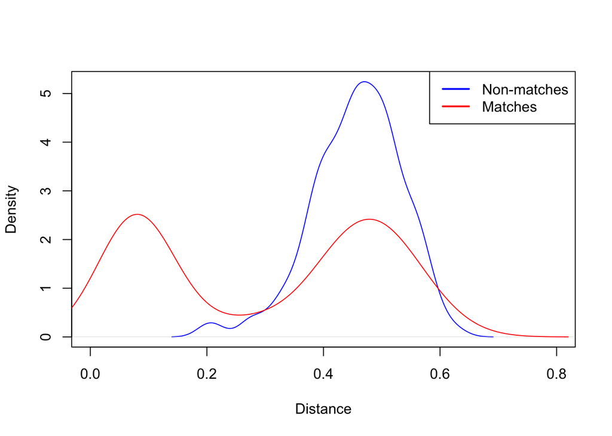

Figure 2: Distribution of distances between true matches and non-matches within blocks

Finally, we compare the evaluation metrics across all ANN algorithms supported by the `blocking()` function, i.e., NND, HNSW, Annoy (from the RcppAnnoy package), Locality-Sensitive Hashing (LSH, from the mlpack package), and $k$-Nearest Neighbours (kNN – denoted as `"kd"`, from the mlpack package). We use the `rec_id` and `ent_id` columns from the `RLdata500` dataset to specify the true blocks and then calculate evaluation metrics for all algorithms.

We compare our package with the `klsh()` function from the klsh package, configured to create 10 blocks (denoted as `klsh_10`) and 100 blocks (denoted as `klsh_100`), respectively. In both settings, we use 20 random projections and 2-character shingles. The results are presented in Table 2, and the code generating it (which also outputs confusion matrices) is included in the Supplementary materials.

Table 2: Comparison of various approximate nearest neighbour algorithms implemented in the blocking and the klsh packages for creation of blocks for deduplication (values in percentages)

|  | precision | fpr | fnr | accuracy | f1_score |
| --- | --- | --- | --- | --- | --- |
| nnd | 5.17 | 0.74 | 0 | 99.26 | 9.83 |
| hnsw | 4.76 | 0.80 | 0 | 99.20 | 9.08 |
| annoy | 4.80 | 0.79 | 0 | 99.21 | 9.17 |
| lsh | 1.04 | 3.74 | 2 | 96.26 | 2.06 |
| kd | 5.19 | 0.73 | 0 | 99.27 | 9.87 |
| klsh_10 | 0.33 | 10.13 | 16 | 89.87 | 0.66 |
| klsh_100 | 3.72 | 0.94 | 10 | 99.06 | 7.14 |

In contrast, the LSH-based methods show more variable behaviour: the mlpack LSH implementation achieves 2% FNR with a higher FPR (3.74%), while the klsh results illustrate a trade-off between block granularity and recall: `klsh_10` with only 10 blocks yields 16% FNR and 10.13% FPR, whereas `klsh_100` with 100 blocks improves to 10% FNR and 0.94% FPR.

We note that this comparison is illustrative rather than exhaustive; the dataset is small and results may differ on larger or noisier data. Nevertheless, the pattern that modern ANN algorithms such as NND, HNSW, and Annoy produce high-recall, low-FPR blocks with minimal configuration is consistent with findings reported elsewhere in the blocking literature (cf. Papadakis et al. (2020)).

## 4 Summary

In this paper, we have demonstrated the basic use cases of the blocking package. We believe that the software will be useful for researchers working in various fields where integration of multiple sources is an important aspect. This is certainly of interest in the field of official statistics, where register-based statistics rely on high-quality linkage of administrative datasets, or medical studies, where assessment of health statistics relies on correct linkage of medical history with treatment outcomes or mortality records.

The package does not currently support Privacy-Preserving Record Linkage; however, the flexibility of the `representation` argument (which accepts user-supplied matrices) provides a natural entry point for integrating encodings such as Bloom filters. Developing and evaluating dedicated PPRL workflows is a direction for future work.

Finally, to extend the package’s ability to block large datasets, we could allow users to use DuckDB (Raasveldt and Mühleisen 2019) via the duckdb package (Mühleisen and Raasveldt 2026). DuckDB smoothly handles large datasets and allows for extensions that implement ANN algorithms (see core and community extensions at https://duckdb.org/).

## 5 Acknowledgements

We thank the three reviewers for their comments. We also thank the participants of the uRos 2024 conference for valuable comments and discussion. Work on this package was supported by the National Science Centre, OPUS 20 grant no. 2020/39/B/HS4/00941.

We have also developed a Python version of the package, [`BlockingPy`](https://blockingpy.readthedocs.io/en/latest/), which is available through PyPI. It has a similar structure but offers more ANN algorithms (e.g., FAISS) and enables the use of embeddings. For more details, see: Strojny and Beręsewicz (2026).

### 5.1 Supplementary materials

Supplementary materials are available in addition to this article. It can be downloaded at paper-blocking.zip

### 5.2 CRAN packages used

reclin2, RecordLinkage, fastLink, PPRL, stringdist, phonics, klsh, blocking, tokenizers, text2vec, ragnar, rnndescent, RcppHNSW, mlpack, RcppAnnoy, igraph, duckdb

### 5.3 CRAN Task Views implied by cited packages

Databases, GraphicalModels, MachineLearning, MissingData, NaturalLanguageProcessing, NetworkAnalysis, OfficialStatistics, Optimization

M. Beręsewicz. Estimation of the number of foreigners in poland [szacunek liczby cudzoziemców w polsce]. 2025. URL https://dsp.stat.gov.pl/dsp2025/slides/sesja_3_problemy_pomiaru/2__beresewiczm.pdf. March 24-25, 2025.

O. Binette and R. C. Steorts. (Almost) all of entity resolution. *Science Advances*, 8(12): eabi8021, 2022. URL https://www.science.org/doi/abs/10.1126/sciadv.abi8021.

P. Christen. A survey of indexing techniques for scalable record linkage and deduplication. *IEEE Transactions on Knowledge and Data Engineering*, 24(9): 1537–1555, 2012a. DOI 10.1109/TKDE.2011.127.

P. Christen. *Data matching: Concepts and techniques for record linkage, entity resolution, and duplicate detection.* Springer, 2012b. URL https://link.springer.com/book/10.1007/978-3-642-31164-2.

P. Christen and K. Goiser. Quality and complexity measures for data linkage and deduplication. In *Quality measures in data mining*, Eds F. Guillet and H. Hamilton pages. 127–151 2007. Springer. DOI 10.1007/978-3-540-44918-8_6.

G. Csardi and T. Nepusz. The igraph software package for complex network research. *InterJournal*, Complex Systems: 1695, 2006. URL https://igraph.org.

G. Csárdi, T. Nepusz, V. Traag, S. Horvát, F. Zanini, D. Noom and K. Müller. *igraph: Network analysis and visualization in r.* 2025. URL https://CRAN.R-project.org/package=igraph. R package version 2.1.4.

R. R. Curtin, M. Edel, O. Shrit, S. Agrawal, S. Basak, J. J. Balamuta, R. Birmingham, K. Dutt, D. Eddelbuettel, R. Garg, et al. Mlpack 4: A fast, header-only c++ machine learning library. *Journal of Open Source Software*, 8(82): 2023. DOI https://doi.org/10.21105/joss.05026.

A. Dasylva and A. Goussanou. Estimating the false negatives due to blocking in record linkage. *Survey Methodology*, 47(2): 299–312, 2021. URL https://www150.statcan.gc.ca/n1/pub/12-001-x/2021002/article/00002-eng.pdf.

A. Dasylva and A. Goussanou. On the consistent estimation of linkage errors without training data. *Japanese Journal of Statistics and Data Science*, 5(1): 181–216, 2022. DOI https://doi.org/10.1007/s42081-022-00153-3.

W. Dong, C. Moses and K. Li. Efficient k-nearest neighbor graph construction for generic similarity measures. In *Proceedings of the 20th international conference on world wide web*, pages. 577–586 2011. New York, NY, USA: Association for Computing Machinery. ISBN 9781450306324. URL https://doi.org/10.1145/1963405.1963487.

D. Eddelbuettel. *RcppAnnoy: “Rcpp” bindings for “Annoy,” a library for approximate nearest neighbors.* 2024. URL https://CRAN.R-project.org/package=RcppAnnoy. R package version 0.0.22.

T. Enamorado, B. Fifield and K. Imai. *fastLink: Fast probabilistic record linkage with missing data.* 2023. URL https://CRAN.R-project.org/package=fastLink. R package version 0.6.1.

T. Enamorado, B. Fifield and K. Imai. Using a probabilistic model to assist merging of large-scale administrative records. *American Political Science Review*, 113(2): 353–371, 2019. DOI https://doi.org/10.1017/S0003055418000783.

I. P. Fellegi and A. B. Sunter. A theory for record linkage. *Journal of the American statistical association*, 64(328): 1183–1210, 1969. DOI https://doi.org/10.1080/01621459.1969.10501049.

D. J. Hand and P. Christen. A note on using the F-measure for evaluating record linkage algorithms. *Statistics and Computing*, 28(3): 539–547, 2018. DOI 10.1007/s11222-017-9746-6.

D. J. Hand, P. Christen and N. Kirielle. F*: An interpretable transformation of the F-measure. *Machine Learning*, 110(3): 451–456, 2021. DOI 10.1007/s10994-021-05964-1.

J. P. Howard II. Phonetic spelling algorithm implementations for r. *Journal of Statistical Software*, 95(8): 1–21, 2020. URL https://www.jstatsoft.org/index.php/jss/article/view/v095i08.

J. P. Howard II. *phonics: Phonetic spelling algorithms in r.* 2021. URL https://jameshoward.us/phonics-in-r/. R package version 1.3.10.

P. Indyk and R. Motwani. Approximate nearest neighbors: Towards removing the curse of dimensionality. In *Proceedings of the 30th annual ACM symposium on theory of computing*, pages. 604–613 1998. DOI 10.1145/276698.276876.

J. Johndrow, K. Lum and D. Dunson. Theoretical limits of microclustering for record linkage. *Biometrika*, 105(2): 431–446, 2018. DOI https://doi.org/10.1093/biomet/asy003.

T. Kalinowski and D. Falbel. *ragnar: Retrieval-augmented generation (RAG) workflows.* 2025. URL https://CRAN.R-project.org/package=ragnar. R package version 0.2.0.

D. E. Knuth. *The art of computer programming, vol. 3: Sorting and searching.* Addison-Wesley, 1973. URL https://dl.acm.org/doi/10.5555/280635.

Y. A. Malkov and D. A. Yashunin. Efficient and robust approximate nearest neighbor search using hierarchical navigable small world graphs. *IEEE transactions on pattern analysis and machine intelligence*, 42(4): 824–836, 2018. DOI https://doi.org/10.1109/tpami.2018.2889473.

J. Melville. *RcppHNSW: “Rcpp” bindings for “hnswlib,” a library for approximate nearest neighbors.* 2024a. URL https://CRAN.R-project.org/package=RcppHNSW. R package version 0.6.0.

J. Melville. *rnndescent: Nearest neighbor descent method for approximate nearest neighbors.* 2024b. URL https://CRAN.R-project.org/package=rnndescent. R package version 0.1.6.

T. Mikolov, K. Chen, G. Corrado and J. Dean. Efficient estimation of word representations in vector space. *arXiv preprint arXiv:1301.3781*, 2013. URL https://arxiv.org/abs/1301.3781.

H. Mühleisen and M. Raasveldt. *Duckdb: DBI package for the DuckDB database management system.* 2026. URL https://CRAN.R-project.org/package=duckdb. R package version 1.4.4.

L. A. Mullen, K. Benoit, O. Keyes, D. Selivanov and J. Arnold. Fast, consistent tokenization of natural language text. *Journal of Open Source Software*, 3: 655, 2018. URL https://doi.org/10.21105/joss.00655.

G. Papadakis, G. Papastefanatos, T. Palpanas and M. Koubarakis. Schema-agnostic vs schema-based configurations for blocking methods on homogeneous data. *Proceedings of the VLDB Endowment*, 9(4): 312–323, 2016. DOI 10.14778/2856318.2856326.

G. Papadakis, D. Skoutas, E. Thanos and T. Palpanas. Blocking and filtering techniques for entity resolution: A survey. *ACM Comput. Surv.*, 53(2): 2020. URL https://doi.org/10.1145/3377455.

M. Raasveldt and H. Mühleisen. DuckDB: An embeddable analytical database. In *Proceedings of the 2019 international conference on management of data*, 2019. New York, NY, USA: ACM. DOI 10.1145/3299869.3320212.

M. Sariyar and A. Borg. *RecordLinkage: Record linkage functions for linking and deduplicating data sets.* 2025. URL https://CRAN.R-project.org/package=RecordLinkage. R package version 0.4-12.5.

M. Sariyar and A. Borg. The RecordLinkage Package: Detecting Errors in Data. *The R Journal*, 2(2): 61–67, 2010. URL https://doi.org/10.32614/RJ-2010-017.

R. Schnell and D. Rukasz. *PPRL: Privacy preserving record linkage.* 2025. URL https://CRAN.R-project.org/package=PPRL. R package version 0.3.9.

D. Selivanov, M. Bickel and Q. Wang. *text2vec: Modern text mining framework for r.* 2023. URL https://CRAN.R-project.org/package=text2vec. R package version 0.6.4.

Y. Singh Parihar, R. Curtin, D. Eddelbuettel and J. Balamuta. *mlpack: “Rcpp” integration for the “mlpack” library.* 2025. URL https://CRAN.R-project.org/package=mlpack. R package version 4.6.2.

R. Steorts. *Klsh: Blocking for record linkage.* 2020. URL https://CRAN.R-project.org/package=klsh. R package version 0.1.0.

R. C. Steorts, S. L. Ventura, M. Sadinle and S. E. Fienberg. A comparison of blocking methods for record linkage. In *Privacy in statistical databases*, Ed J. Domingo-Ferrer pages. 253–268 2014. Cham: Springer International Publishing. ISBN 978-3-319-11257-2. DOI https://doi.org/10.1007/978-3-319-11257-2_20.

T. Strojny and M. Beręsewicz. BlockingPy: Approximate nearest neighbours for blocking of records for entity resolution. *SoftwareX*, 34: 102583, 2026. URL https://doi.org/10.1016/j.softx.2026.102583.

J. van der Laan. reclin2: A toolkit for record linkage and deduplication. *R Journal*, 14(2): 2022. URL https://journal.r-project.org/articles/RJ-2022-038/.

J. van der Laan. *reclin2: Record linkage toolkit.* 2024. URL https://CRAN.R-project.org/package=reclin2. R package version 0.5.0.

M. P. J. van der Loo. The stringdist package for approximate string matching. *The R Journal*, 6: 111–122, 2014. URL https://CRAN.R-project.org/package=stringdist.

M. Wang, X. Xu, Q. Yue and Y. Wang. A comprehensive survey and experimental comparison of graph-based approximate nearest neighbor search. *Proceedings of the VLDB Endowment*, 14(11): 1964–1978, 2021. DOI 10.14778/3476249.3476255.